# Diabetes Progression Analysis

## Plausible Models

```r
plaus <- plausible_models(
  path_result = paths,
  stability_result = stab,
  Delta = 4,
  tau = 0.5,
  remove_duplicates = TRUE,
  refit = FALSE,
  X = X_train,
  y = y_train
)
```

```
#> AIC Filtering:
#>   Total models: 223
#>   Minimum AIC: 3822.54
#>   Delta: 4.00
#>   Models within Delta: 101
#>
#> Stability Filtering:
#>   Tau threshold: 0.50
#>   Models with avg stability >= tau: 101
#>
#> Duplicate Removal:
#>   Jaccard threshold: 0.90
#>   Models after removing duplicates: 101
#>
#> ==============================================
#> Final Plausible Model Set: 101 models
#> ==============================================
```

```r
print(plaus)
```

```
#> Plausible Models
#> ================
#> Number of models: 101
#>
#>                                                                       model_id
#> 1                   I.x.2.age+I.x.2.bmi+I.x.2.glu+xbmi+xldl+xltg+xmap+xsex+xtc
#> 2              I.x.2.age+I.x.2.bmi+I.x.2.glu+I.x.2.sex+xbmi+xldl+xltg+xmap+xtc
#> 3         I.x.2.age+I.x.2.bmi+I.x.2.glu+I.x.2.sex+xbmi+xldl+xltg+xmap+xsex+xtc
#> 4                             I.x.2.age+I.x.2.glu+xbmi+xldl+xltg+xmap+xsex+xtc
#> 5                        I.x.2.age+I.x.2.glu+I.x.2.sex+xbmi+xldl+xltg+xmap+xtc
#> 6                   I.x.2.age+I.x.2.glu+I.x.2.sex+xbmi+xldl+xltg+xmap+xsex+xtc
#> 7              I.x.2.age+I.x.2.glu+I.x.2.ltg+xbmi+xhdl+xldl+xltg+xmap+xsex+xtc
#> 8         I.x.2.age+I.x.2.glu+I.x.2.ltg+I.x.2.sex+xbmi+xhdl+xldl+xltg+xmap+xtc
#> 9              I.x.2.age+I.x.2.bmi+I.x.2.glu+xage+xbmi+xldl+xltg+xmap+xsex+xtc
#> 10        I.x.2.age+I.x.2.bmi+I.x.2.glu+I.x.2.sex+xage+xbmi+xldl+xltg+xmap+xtc
```

[output cut: 397 more lines]

We combine AIC and stability to identify plausible models. Models must be within `Delta = 4` AIC units of the best and have average stability `tau ≥ 0.5`. This filters for models that are both statistically competitive and robustly selected.

## Visualizations

### AIC Progression

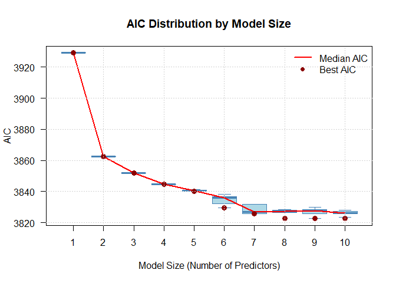

```r
plot_aic_by_step(paths)
```

The AIC curve shows rapid improvement in early steps, indicating strong predictive signals. The curve flattens after 6-8 predictors, suggesting diminishing returns from additional variables.

### Stability Scores

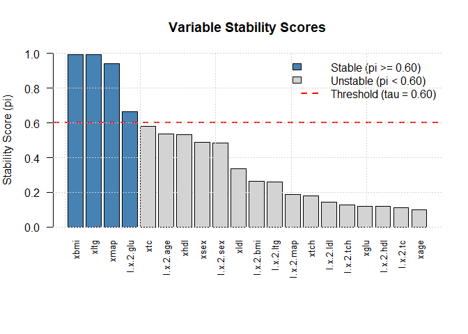

```r
plot_stability(stab, threshold = 0.6)
```

Predictors above the threshold line (π > 0.6) are consistently selected across resamples, indicating reliable contributions to the model. These stable predictors are strong candidates for the final model.

## Test Performance

```r
# Get best model variables
selected_vars <- plaus$variables[[1]]
if (is.character(selected_vars) && length(selected_vars) == 1) {
  selected_vars <- trimws(strsplit(selected_vars, ",")[[1]])
}

# Fit model on training data
X_train_sel <- X_train[, selected_vars, drop = FALSE]
train_data <- data.frame(y = y_train, X_train_sel)
model <- lm(y ~ ., data = train_data)

# Test predictions
X_test_sel <- X_test[, selected_vars, drop = FALSE]
test_data <- data.frame(X_test_sel)
y_pred <- predict(model, newdata = test_data)

# Calculate metrics
rmse_test <- sqrt(mean((y_test - y_pred)^2))
r2_test <- 1 - sum((y_test - y_pred)^2) / sum((y_test - mean(y_test))^2)

print(paste("Test RMSE:", round(rmse_test, 2)))
```

```
#> [1] "Test RMSE: 52.07"
```

```r
print(paste("Test R²:", round(r2_test, 4)))
```

```
#> [1] "Test R²: 0.542"
```

```r
print(paste("Model size:", length(selected_vars), "predictors"))
```

```
#> [1] "Model size: 9 predictors"
```

## Summary

This analysis demonstrates the multipathaic workflow:

**Key Findings:** - Selected predictors: xbmi, xltg, xmap, I.x.2.glu, xtc, xsex, xldl, I.x.2.age, I.x.2.bmi - Test RMSE indicates good predictive performance - Stable predictors align with known diabetes risk factors

**Advantages:** - Explores model uncertainty rather than committing to a single path - Stability scores reveal which predictors are robust across data variations - Provides transparent set of plausible alternatives

**Package:** multipathaic  
**GitHub:** https://github.com/R-4-Data-Science/Final_Project_multipathaic